# Case study 1: Constant growth with SUSTAIN Trout data

## Overview

In circumstances where the number of observations available per individual is very limited, average growth rates over time may be the only plausible model to fit. In particular, if there are individuals with only two size observations, than the best that can be done is a single estimate of growth rate based on that interval. Such a model behaves as **constant growth**, which we can think of as the average rate of change across the observation period and is given by
$$\begin{equation}\tag{3}\label{eqn_3_const}
f(Y(t), \beta) = \beta
\end{equation}$$
where $\beta$ is the average growth rate. The constant growth model corresponds to linear sizes over time, and is equivalent to a linear mixed model for size, where there is an individual effect when fit to multiple individuals.

### Load dependencies

```r
# remotes::install_github("traitecoevo/hmde")
# install.packages(c("dplyr", "ggplot2"))

library(hmde)
library(dplyr)
library(ggplot2)
```

### Priors

The default priors for the constant top-level parameters in the single individual model are
$$\beta\sim
\log\mathcal{N}(0, 2),$$
$$0
<\sigma_e \sim Cauchy(0, 2).$$

For the multi-individual model the prior structure and default parameters are
$$\mu_{\beta} \sim
\mathcal{N}(0, 2),$$
$$0 <
\sigma_{\beta} \sim Cauchy(0, 2),$$
$$0 < \sigma_{e} \sim Cauchy(0, 2).$$
To change the prior parameter values (the distributions are fixed) optional arguments can be passed to `hmde_assign_data` with names corresponding to the `prior_pars` argument for the associated parameter as output by `hmde_models()`. For example in the following we want to change the prior for $\beta$ (`ind_beta`) in the individual model:

```r
hmde_model("constant_single_ind")
```

```
#> [1] "Model: constant_single_ind"
#> [1] "Input data template:"
#> $n_obs
#> NULL
#>
#> $y_obs
#> NULL
#>
#> $obs_index
#> NULL
#>
#> $time
#> NULL
#>
#> $prior_pars_ind_beta
#> [1] 0 2
#>
#> $prior_pars_global_error_sigma
#> [1] 0 2
#>
#> $model
#> [1] "constant_single_ind"
```

```r
#prior_pars_ind_beta is the argument name for the prior parameters
```

The mean passed to a log-normal distribution is the mean of the **underlying normal distribution**, so if you want to pass a value based on raw observations you need to log-transform it first.

Let’s simulate some data to visualise the constant growth function.

### Simulate data

```r
beta <- 2 #Annual growth rate
y_0 <- 1 #Starting size
time <- 0:20
sizes_over_time <- tibble(Y_t = 1 + beta*time, #Linear sizes over time
                          t = time)

sizes_over_time
```

```
#> # A tibble: 21 × 2
#>      Y_t     t
#>    <dbl> <int>
#>  1     1     0
#>  2     3     1
#>  3     5     2
#>  4     7     3
#>  5     9     4
#>  6    11     5
#>  7    13     6
#>  8    15     7
#>  9    17     8
#> 10    19     9
#> # ℹ 11 more rows
```

### Visualise data

Here are some plots to demonstrate how the constant growth function relates to sizes over time for a single individual. Feel free to play around with the parameter settings (`beta`, `y_0`) and see how the plot changes.

[figure not shown]

```r
#Plot of growth function
ggplot() +
  geom_function(fun = hmde_model_des("constant_single_ind"), # Visualising the growth function
                args = list(pars = list(beta)),
                colour = "green4", linewidth=1,
                xlim = c(y_0, max(sizes_over_time))) +
  xlim(y_0, max(sizes_over_time$Y_t)) + # Creating the x axis
  ylim(0, beta*2) + # Creating the y axis
  labs(x = "Y(t)", y = "f", title = "Constant growth") + # Axe labels and plot title
  theme_classic() + # Theme for the plot
  theme(axis.text=element_text(size=16), # Plot customising
        axis.title=element_text(size=18,face="bold"))

#Sizes over time
ggplot(data = sizes_over_time, aes(x=t, y = Y_t)) +
  geom_line(colour="green4", linewidth=1) + # Line graph of sizes_over_time
  xlim(0, max(sizes_over_time$t)) +
  ylim(0, max(sizes_over_time$Y_t)*1.05) +
  labs(x = "Time", y = "Y(t)", title = "Constant growth") +
  theme_classic() +
  theme(axis.text=element_text(size=16),
        axis.title=element_text(size=18,face="bold"))
```

A key take-away of the function plot (on the left) is the relationship to what we think of as a “reasonable growth model”. We don’t expect constant growth rates to be realistic, at best they represent the average rate of change over a period. More complex models may be more realistic, but in this case study we are only interested in different mechanisms of size dependence, we do not use environmental covariates for example.

## SUSTAIN trout data

Our example data for the constant model comes from Moe et al. (2020), a publicly available dataset of mark-recapture data for *Salmo trutta* in Norway. The time between observations is not controlled, nor is the number of observations per individual. As a result the data consists primarily of individuals with two observations of size, constituting a single observation of growth which limits the growth functions that can be fit to individuals as a single parameter model is the best that can be fit to two sizes. The constant growth function in Equation $\eqref{eqn_3_const}$ is the most appropriate of the functions we have in `hmde`, as we can interpret the single growth interval as an estimate of the average growth rate that gets fit to $\beta$.

In order to best reflect the survey data we took a stratified sample of individuals grouped by the number of available observations. We have 25 fish with two observations, 15 with three, 10 with four, for a total sample size of 50. This data is included with `hmde`

```r
Trout_Size_Data
```

```
#> # A tibble: 135 × 4
#>    ind_id  time y_obs obs_index
#>     <dbl> <dbl> <dbl>     <dbl>
#>  1      1  0       52         1
#>  2      1  1.91    60         2
#>  3      1  4.02    70         3
#>  4      1  6.04    80         4
#>  5      2  0       80         1
#>  6      2  1.90    85         2
#>  7      2  3.94    93         3
#>  8      2  5.96    94         4
#>  9      3  0       52         1
#> 10      3  2.03    65         2
#> # ℹ 125 more rows
```

### Transform data

As initial exploration we will have a look at the distribution of observed sizes, growth behaviour, and observation intervals. First we transform the data to extract growth increment and observation interval information, then plot it.

```r
Trout_Size_Data_transformed <- Trout_Size_Data %>%
  group_by(ind_id) %>%
  mutate(
    delta_y_obs = y_obs - lag(y_obs),
    obs_interval = time - lag(time),
    obs_growth_rate = delta_y_obs/obs_interval
  ) %>%
  ungroup()

Trout_Size_Data_transformed
```

```
#> # A tibble: 135 × 7
#>    ind_id  time y_obs obs_index delta_y_obs obs_interval obs_growth_rate
#>     <dbl> <dbl> <dbl>     <dbl>       <dbl>        <dbl>           <dbl>
#>  1      1  0       52         1          NA        NA             NA
#>  2      1  1.91    60         2           8         1.91           4.18
#>  3      1  4.02    70         3          10         2.11           4.75
#>  4      1  6.04    80         4          10         2.02           4.96
#>  5      2  0       80         1          NA        NA             NA
#>  6      2  1.90    85         2           5         1.90           2.64
#>  7      2  3.94    93         3           8         2.04           3.92
#>  8      2  5.96    94         4           1         2.03           0.494
#>  9      3  0       52         1          NA        NA             NA
#> 10      3  2.03    65         2          13         2.03           6.42
#> # ℹ 125 more rows
```

### Visualise raw data

Let’s create some histograms to investigate the distribution of size, growth interval and growth increments.

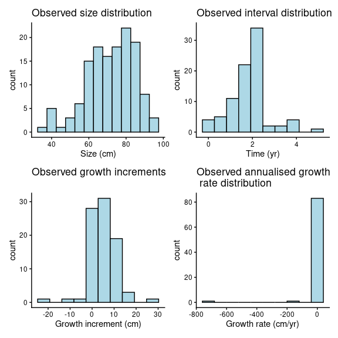

The growth histograms show that there’s a number of negative growth increments, some reasonably extreme, and when combined with some short observation periods we get very extreme estimates of growth rates. We can further investigate these if needed.

The constant growth model assumes non-negative growth and uses a log-normal distribution for $\beta$, which will eliminate those increments from the estimated sizes. We consider eliminating negative growth biologically reasonable as we don’t expect the length of fish to decrease over time, even if their mass or width might.

### Fit model using {hmde}

Now we will actually fit the model and extract the estimates.

You can see what data structures are needed for the constant growth model through the following methods:

```r
hmde_model("constant_multi_ind") |>
  names()
```

```
#>  [1] "n_obs"                         "n_ind"
#>  [3] "y_obs"                         "obs_index"
#>  [5] "time"                          "ind_id"
#>  [7] "prior_pars_pop_log_beta_mean"  "prior_pars_pop_log_beta_sd"
#>  [9] "prior_pars_global_error_sigma" "model"
```

```r
print(hmde_model("constant_multi_ind"))
```

```
#> [1] "Model: constant_multi_ind"
#> [1] "Input data template:"
#> $n_obs
#> NULL
#>
#> $n_ind
#> NULL
#>
#> $y_obs
#> NULL
#>
#> $obs_index
#> NULL
#>
#> $time
#> NULL
#>
#> $ind_id
#> NULL
#>
#> $prior_pars_pop_log_beta_mean
#> [1] 0 2
#>
#> $prior_pars_pop_log_beta_sd
#> [1] 0 2
#>
#> $prior_pars_global_error_sigma
#> [1] 0 2
#>
#> $model
#> [1] "constant_multi_ind"
```

```r
summary(hmde_model("constant_multi_ind"))
```

```
#> [1] "Model: constant_multi_ind"
#> [1] "Input data template:"
#> $n_obs
#> NULL
#>
#> $n_ind
#> NULL
#>
#> $y_obs
#> NULL
#>
#> $obs_index
#> NULL
#>
#> $time
#> NULL
#>
#> $ind_id
#> NULL
#>
#> $prior_pars_pop_log_beta_mean
#> [1] 0 2
#>
#> $prior_pars_pop_log_beta_sd
#> [1] 0 2
#>
#> $prior_pars_global_error_sigma
#> [1] 0 2
#>
#> $model
#> [1] "constant_multi_ind"
```

Each name represents an element of the list that gets passed to the model: - `n_obs` is the integer number of observations $y_{ij}$ - `n_ind` is the integer number of individuals - `y_obs` is the vector of $y_{ij}$ observations and should have length `n_obs` - `obs_index` is a vector containing integer the $j$ index for individual $i$, and counts which observation $y_{ij}$ is in sequence - `time` is a vector that determines when an observation happened relative to the first observation for that individual. The first observation has time 0 - `ind_id` is a vector the same length as `y_obs` that tracks which individual an observation comes from - `prior_pars_pop_log_beta_mean` is the vector of prior parameters for the log-beta mean hyper-parameter - `prior_pars_pop_log_beta_sd` is the vector of prior parameters for the log-beta standard deviation hyper-parameter - `prior_pars_global_error_sigma` is the vector of prior parameters for the global error standard deviation - `model` is the name of the model

Now we will actually fit the model and extract the estimates. As the provided trout data is already in the form required by the `hmde_assign_data` function we don’t need to do any further re-naming and can pass it directly.

```r
trout_constant_fit <- hmde_model("constant_multi_ind") |>
  hmde_assign_data(data = Trout_Size_Data)  |>
  hmde_run(chains = 4, cores = 1, iter = 2000)
```

We have included two specialist diagnostic tools in the package to give easy access to the $\hat{R}$ statistics of chain convergence and mixing.

```r
# Returns a list of R_hat values
hmde_extract_Rhat(trout_constant_fit)
```

```
#>            ind_y_0            ind_y_0            ind_y_0            ind_y_0
#>          1.0007317          1.0019942          1.0010176          1.0014778
#>            ind_y_0            ind_y_0            ind_y_0            ind_y_0
#>          1.0000438          1.0016832          1.0018618          1.0006909
#>            ind_y_0            ind_y_0            ind_y_0            ind_y_0
#>          1.0002140          1.0013925          1.0005765          1.0005702
#>            ind_y_0            ind_y_0            ind_y_0            ind_y_0
#>          0.9999210          1.0004595          1.0015869          1.0020733
#>            ind_y_0            ind_y_0            ind_y_0            ind_y_0
#>          1.0005974          1.0002044          1.0012317          1.0007854
#>            ind_y_0            ind_y_0            ind_y_0            ind_y_0
#>          1.0006107          1.0013101          1.0005090          1.0010638
#>            ind_y_0            ind_y_0            ind_y_0            ind_y_0
#>          1.0003840          1.0001889          1.0004834          1.0013441
#>            ind_y_0            ind_y_0            ind_y_0            ind_y_0
#>          1.0016836          1.0005578          1.0009309          1.0007621
#>            ind_y_0            ind_y_0            ind_y_0            ind_y_0
#>          1.0003825          1.0011154          1.0002029          1.0011187
#>            ind_y_0            ind_y_0            ind_y_0            ind_y_0
#>          1.0002190          1.0001166          1.0015816          1.0030744
#>            ind_y_0            ind_y_0            ind_y_0            ind_y_0
#>          1.0002377          1.0005715          1.0008362          1.0014354
#>            ind_y_0            ind_y_0            ind_y_0            ind_y_0
#>          1.0017633          1.0005130          1.0007685          1.0019734
#>            ind_y_0            ind_y_0           ind_beta           ind_beta
#>          1.0005679          1.0010265          1.0013151          1.0018740
#>           ind_beta           ind_beta           ind_beta           ind_beta
#>          1.0020772          1.0004692          0.9999928          1.0009163
#>           ind_beta           ind_beta           ind_beta           ind_beta
#>          1.0005410          1.0001185          1.0014444          1.0003794
#>           ind_beta           ind_beta           ind_beta           ind_beta
#>          1.0009960          0.9999819          1.0005073          1.0017408
#>           ind_beta           ind_beta           ind_beta           ind_beta
#>          1.0007063          1.0016846          1.0007242          1.0014864
#>           ind_beta           ind_beta           ind_beta           ind_beta
#>          1.0006325          1.0005790          1.0011926          1.0017633
#>           ind_beta           ind_beta           ind_beta           ind_beta
#>          1.0003583          1.0019396          1.0006710          1.0005437
#>           ind_beta           ind_beta           ind_beta           ind_beta
#>          1.0005801          1.0003829          1.0007730          1.0007077
```

[output cut: 65 more lines]

```
#>          1.0002377          1.0000740          1.0005715          1.0013133
#>              y_hat              y_hat              y_hat              y_hat
#>          1.0012988          1.0008362          1.0009493          1.0004696
#>              y_hat              y_hat              y_hat              y_hat
#>          1.0014354          1.0006873          1.0009361          1.0017633
#>              y_hat              y_hat              y_hat              y_hat
#>          1.0014528          1.0005130          1.0001229          1.0006958
#>              y_hat              y_hat              y_hat              y_hat
#>          1.0007685          1.0004441          1.0002652          1.0019734
#>              y_hat              y_hat              y_hat              y_hat
#>          1.0008562          1.0007456          1.0010951          1.0005679
#>              y_hat              y_hat              y_hat              y_hat
#>          1.0006232          1.0012613          1.0003775          1.0010265
#>              y_hat              y_hat               lp__
#>          1.0005818          1.0015448          1.0063307
```

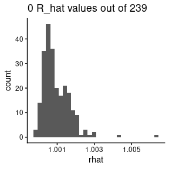

```r
# Returns a histogram of R_hat values
hmde_plot_Rhat_hist(trout_constant_fit)
```

These functions exclude the $\hat{R}$ values associated with the generated quantites, as these have 0 variance and thus produce NAs.

### Inspect estimates

Once the model has finished running, we can extract the model estimates and have a look at the distribution of estimated sizes, estimated growth increments, and annualised growth rates at the level of sizes over time.

```r
trout_constant_estimates <- hmde_extract_estimates(
                                 fit = trout_constant_fit,
                                 input_measurement_data = Trout_Size_Data)
```

First, let’s do some quick data wrangling to calculate our parameters of interest.

```r
measurement_data_transformed <- trout_constant_estimates$measurement_data %>%
  group_by(ind_id) %>%
  mutate(
    delta_y_obs = y_obs - lag(y_obs),
    obs_interval = time - lag(time),
    obs_growth_rate = delta_y_obs/obs_interval,
    delta_y_est = y_hat - lag(y_hat),
    est_growth_rate = delta_y_est/obs_interval
  ) %>%
  ungroup()
```

Now we can have a look at the distribution of each of the estimated parameter by creating histograms

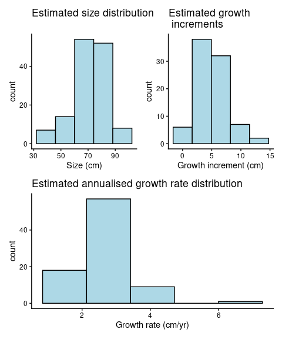

```r
est_hist_y_hat <- histogram_func(measurement_data_transformed, y_hat,
               "Estimated size distribution",
               xlab = "Size (cm)",
               bins = 5)

est_hist_delta_y_est <-  histogram_func(measurement_data_transformed, delta_y_est,
               "Estimated growth  \n increments",
               xlab = "Growth increment (cm)",
               bins = 5)

est_hist_growth_rate <- histogram_func(measurement_data_transformed, est_growth_rate,
               "Estimated annualised growth rate distribution", xlab = "Growth rate (cm/yr)",
               bins = 5)

(est_hist_y_hat + est_hist_delta_y_est) / est_hist_growth_rate
```

We can see that the negative growth increments are gone! Because we fit a positive growth function ($f = \beta > 0$) the model cannot actually estimate negative growth increments.

#### $R^2$

We can also directly compare the observed sizes over time to estimated values.

We can use $R^2$ calculated on $(y_{ij}, \hat{Y}_{ij})$, and inspect we can look at plots of sizes over time. The $R^2$ statistic is a metric primarily used in linear regression that measures the proportion (ie. decimal value in the [0,1] interval) of variance in one coordinate that can be explained by the regression model. In this context, we interpret it as how strongly the fitted and observed values agree. We don’t expect perfect agreement – $R^2=1$ – because we don’t get perfect agreement. O’Brien, Warton, and Falster (2024) showed that the change between observed and fitted values can actually correct for measurement errors in size, so disagreement is not a bad thing overall.

In the next block, we are looking at 5 random individuals to start with because plotting every individuals’ sizes over time can get very messy.

```r
#Quantitative R^2
cor(measurement_data_transformed$y_obs, measurement_data_transformed$y_hat)^2
```

```
#> [1] 0.9530432
```

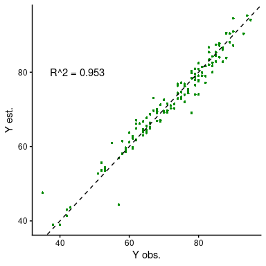

```r
r_sq_est <- cor(trout_constant_estimates$measurement_data$y_obs,
                          trout_constant_estimates$measurement_data$y_hat)^2
r_sq <- paste0("R^2 = ",
               signif(r_sq_est,
                      digits = 3))

obs_est_size_plot <- ggplot(data = trout_constant_estimates$measurement_data,
       aes(x = y_obs, y = y_hat)) +
  geom_point(shape = 16, size = 1, colour = "green4") +
  xlab("Y obs.") +
  ylab("Y est.") +
  geom_abline(slope = 1, linetype = "dashed") +
  annotate("text", x = 45, y = 80,
           label = r_sq) +
  theme_classic()
obs_est_size_plot
```

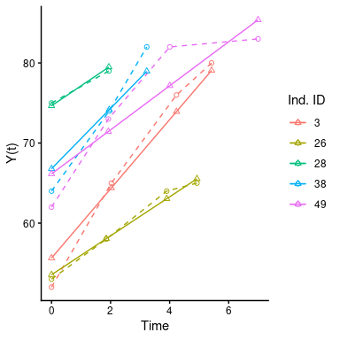

```r
#Plots of size over time for a sample of 5 individuals
size_over_time_plot <- hmde_plot_obs_est_inds(n_ind_to_plot = 5,
                       measurement_data = trout_constant_estimates$measurement_data)
size_over_time_plot
```

### Individual growth functions ($\beta$)

At the level of individuals we are interested in the distribution of $\beta$ estimates, which will align with the estimated annualised growth rates as that’s precisely what they represent. Here is one way to visualise the fitted growth functions in order to see how they compare to the observed sizes.

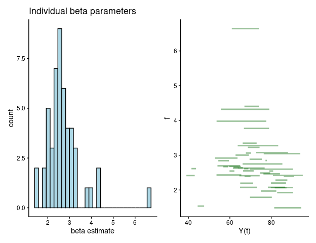

### Population hyper-parameters

We also get estimates of the population-level hyper-parameters that govern the distribution of $\beta$ – $\mu$ and $\sigma$ for the log-normal distribution. These are calculated in the context of the log-transformed parameters so the easiest way to interpret $\mu$ is to back-transform it through exponentiation, but this does not so easily transfer to $\sigma$. The CIs in this output are posterior credible intervals taken as the central 95% quantiles of the posterior samples.

```r
#Mean of normal distribution
trout_constant_estimates$population_data$mean[1] #Raw value
```

```
#> [1] 0.8830566
```

```r
print(paste0("95% CI for mean log growth: (",
             trout_constant_estimates$population_data$CI_lower[1], " , ",
             trout_constant_estimates$population_data$CI_upper[1], ")")) #Raw CI
```

```
#> [1] "95% CI for mean log growth: (0.592074850511751 , 1.11691345400801)"
```

```r
exp(trout_constant_estimates$population_data$mean[1]) #In cm/yr units
```

```
#> [1] 2.41828
```

```r
print(paste0("95% CI for mean growth in cm/yr: (",
             exp(trout_constant_estimates$population_data$CI_lower[1]), " , ",
             exp(trout_constant_estimates$population_data$CI_upper[1]), ")"))
```

```
#> [1] "95% CI for mean growth in cm/yr: (1.807735307461 , 3.05540897390178)"
```

```r
#Standard deviation of underlying normal distribution
trout_constant_estimates$population_data$mean[2]
```

```
#> [1] 0.4741917
```

```r
print(paste0("95% CI for log growth standard deviation: (",
             trout_constant_estimates$population_data$CI_lower[2], " , ",
             trout_constant_estimates$population_data$CI_upper[2], ")")) #Raw CI
```

```
#> [1] "95% CI for log growth standard deviation: (0.150207692370042 , 0.824192149917586)"
```

## References

Moe, S Jannicke, Chloé R Nater, Atle Rustadbakken, L Asbjørn Vøllestad, Espen Lund, Tore Qvenild, Ola Hegge, and Per Aass. 2020. “Long-Term Mark-Recapture and Growth Data for Large-Sized Migratory Brown Trout (Salmo Trutta) from Lake Mjøsa, Norway.” *Biodiversity Data Journal* 8.

O’Brien, Tess, David Warton, and Daniel Falster. 2024. “Yes, They’re All Individuals: Hierarchical Models for Repeat Survey Data Improve Estimates of Tree Growth and Sie.” *Methods in Ecology and Evolution*.